## Introduction

Predicting words is a task that can help a user when writing text on a mobile phone. With small displays it can be cumbersome and lengthy to write texts. Therefore, modern software keyboards offer some suggestions to the user that could be written next with one single click. The overall goal of the project is to develop an algorithm that predicts the next word a user will type on his mobile phone (or on a website) given this previous input. To achieve this, we will employ a machine learning algorithm that calculates the probabilities of the next word to be entered so the most likely word is suggested. Since the algorithm needs some data to learn from, we use the provided data set from [SwiftKey](https://d396qusza40orc.cloudfront.net/dsscapstone/dataset/Coursera-SwiftKey.zip).

## Information On The Training Set

The training set consists of three files for each language containing texts from news websites, blogs and twitter.

We will use the English language files in the following text.

### General Properties

We first take a look at the general properties of the files provided in the data set before executing a deeper analysis of the content.

| set | lines | characters | letters | whitespace | punctuation | digits | words | sentences |
| --- | --- | --- | --- | --- | --- | --- | --- | --- |
| blogs | 899288 | 209260725 | 162800902 | 37334130 | 5822618 | 985537 | 37334131 | 2530958 |
| news | 1010242 | 204801646 | 160529414 | 34372529 | 6766462 | 2259419 | 34372530 | 2268107 |
| twitter | 2360148 | 164744972 | 124977127 | 30373544 | 7955343 | 1015463 | 30373543 | 4346303 |

From the table we can observe some interesting characteristics. For example the 140 character limit on twitter can clearly be observed. The file has the most lines of text but at the same time fewer chacters compared to the other files. In the news file the number of digits is more than twice the number compared to the other two files. This could be explained by the nature of the content as news articles often state precise numbers in the text.

## Tokenization

In this chapter we have a look at the frequencies of words and **n-grams**. An n-gram is a contiguous sequence of $n$ items - in our case words - which can be formed from the texts in our data set.

To get an impression of the frequencies of words and n-grams, take 100000 random samples from each three data sets.

### Frequencies Of Words

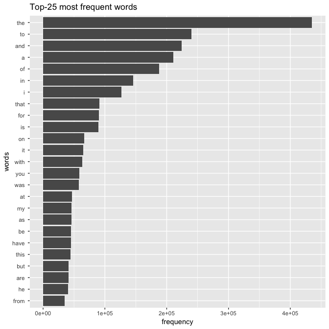

The most frequent words in the data are common stop words, i.e. words that in some other natual language computing context are unwanted and should be removed. Examples are *the*, *and*, *of*, *to* and many more. In our case, however, they cannot be dropped as they are potential candidates for our prediction algorithm.

### Analysis Of Bigrams (2-grams)

Now we look at the bigrams, i.e. couples of words.

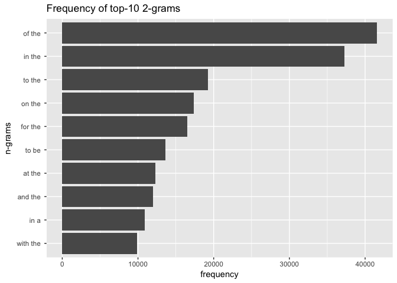

One remarkable observation is that many bigrams contain the word “the” which is also the most frequent word.

### Analysis of trigrams (3-grams)

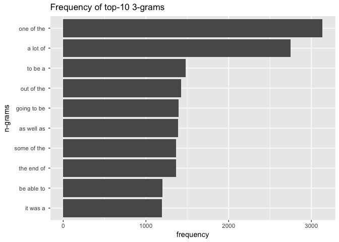

Among the most frequent trigrams there already are some comon phases like “a lot of” or “one of the”.

### Analysis of four-grams (4-grams)

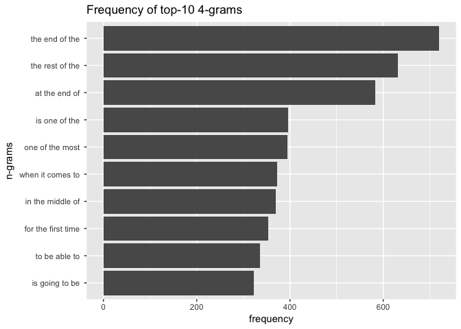

### Analysis of five-grams (5-grams)

Finally, we have a look at the 5-grams for which we again provide the ten most frequent ones in the following figure.

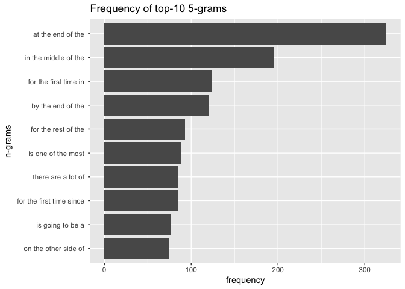

To see how the n-gram’s frequencies can be used to calculate probabilities of words see the prediction algorithms tab.

## Cleansing The Strings

Every non-tidy data set needs some preprocessing steps to obtain a usable set of data to work with. For the text files we used some regular expressions to remove

- URLs,
- numbers,
- twitter names and hashtags,
- email adresses,
- symbols,
- punctuation.

Also, we converted all words to lower case.

## Optimizations

In order to have a fast response time we used the `data.table` package that extends the standard data.frame in several ways. The best addition is the possibility to index certain columns which allows for extremely fast look-ups. The data.table uses binary search which operates super efficiently on sorted arrays.

To minimize the memory footprint we only used n-grams that occured more than four times in our training set. We also removed entries for which the score was too bad within the group of word sequences that did only differ in the last word. This allowed the reduction to only 25MB of memory. If one would want to implent this for a mobile device, there would very likely be more room for improvements…

The following graph shows the influence of the threshold on the accuracy scores calculated by the benchmark from [Hernán Foffani](https://github.com/hfoffani/dsci-benchmark).

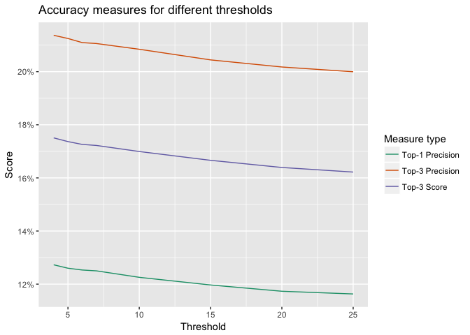